# Data 524 Assignment 2

Warner Alexis

2025-02-16

## Time Series Decomposition

**Excercise 3.1**

Consider the GDP information in global_economy. Plot the GDP per capita for each country over time. Which country has the highest GDP per capita? How has this changed over time?

The plot shows GPD per capita trends over time and the country with the higehst GDP per Capita is Monaco (MCO)

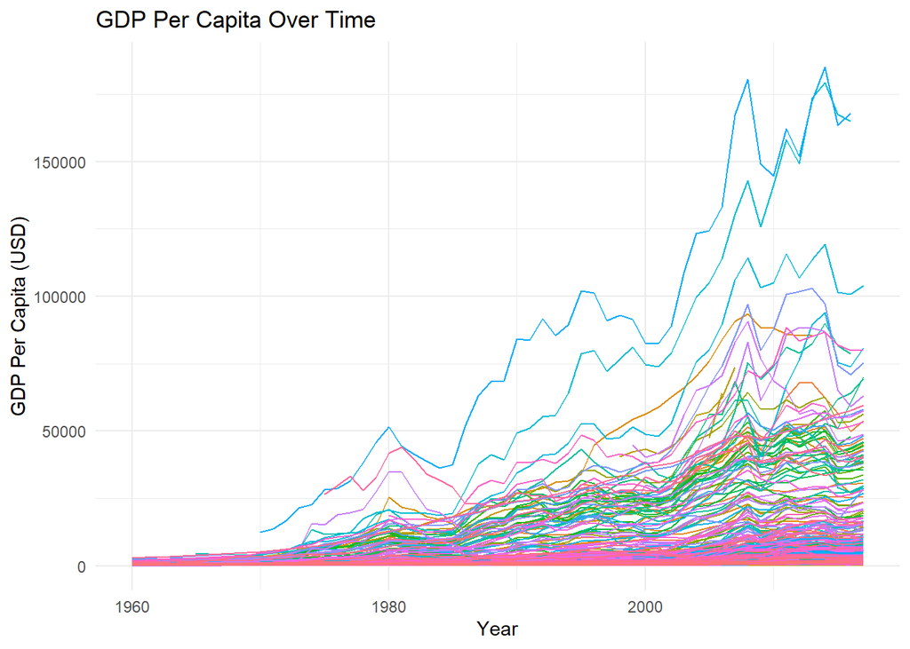

```
## # A tsibble: 1 x 10 [1Y]
## # Key:       Country [1]
##   Country Code   Year         GDP Growth   CPI Imports Exports Population
##   <fct>   <fct> <dbl>       <dbl>  <dbl> <dbl>   <dbl>   <dbl>      <dbl>
## 1 Monaco  MCO    2014 7060236168.   7.18    NA      NA      NA      38132
## # ℹ 1 more variable: GDPperCapita <dbl>
```

**Excercise 3.2** For each of the following series, make a graph of the data. If transforming seems appropriate, do so and describe the effect.

- United States GDP from global_economy.
- Slaughter of Victorian “Bulls, bullocks and steers” in aus_livestock.
- Victorian Electricity Demand from vic_elec. = Gas production from aus_production.

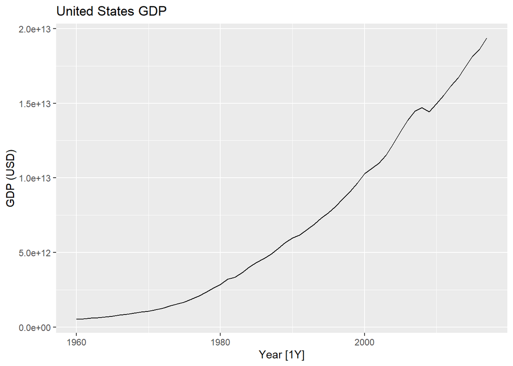

```r
library(fpp3)

# 1. United States GDP from global_economy
us_gdp <- global_economy %>%
  filter(Country == "United States") %>%
  select(Year, GDP)

# Plot US GDP
us_gdp %>%
  autoplot(GDP) +
  labs(title = "United States GDP", y = "GDP (USD)")
```

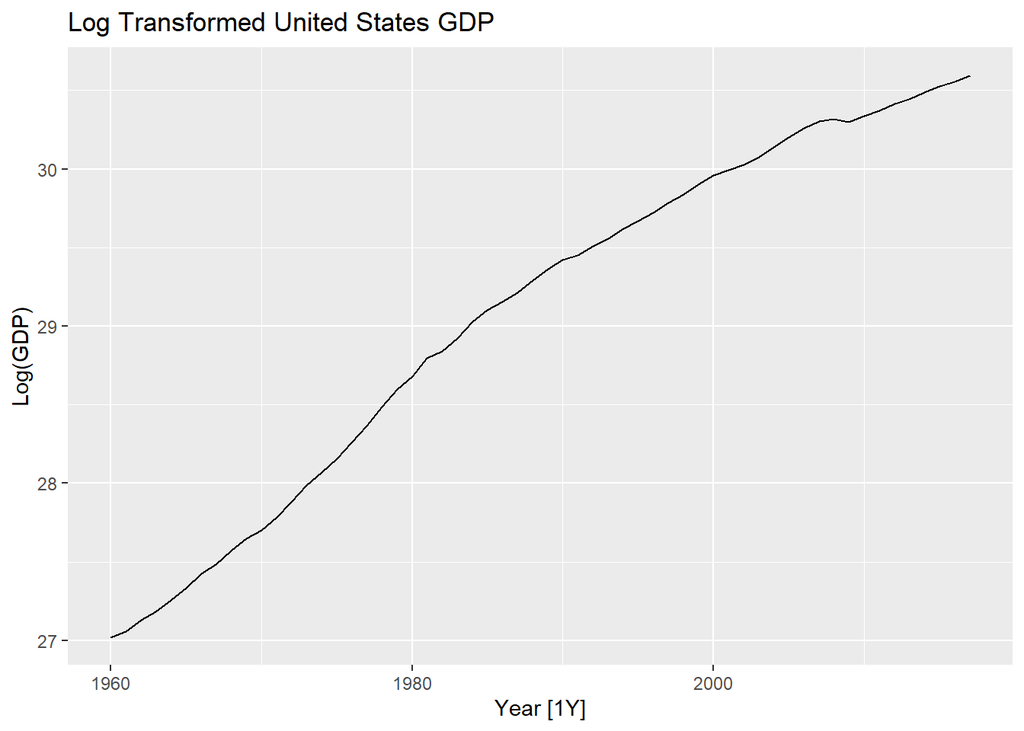

```r
# Log transformation (if necessary)
us_gdp %>%
  mutate(log_GDP = log(GDP)) %>%
  autoplot(log_GDP) +
  labs(title = "Log Transformed United States GDP", y = "Log(GDP)")
```

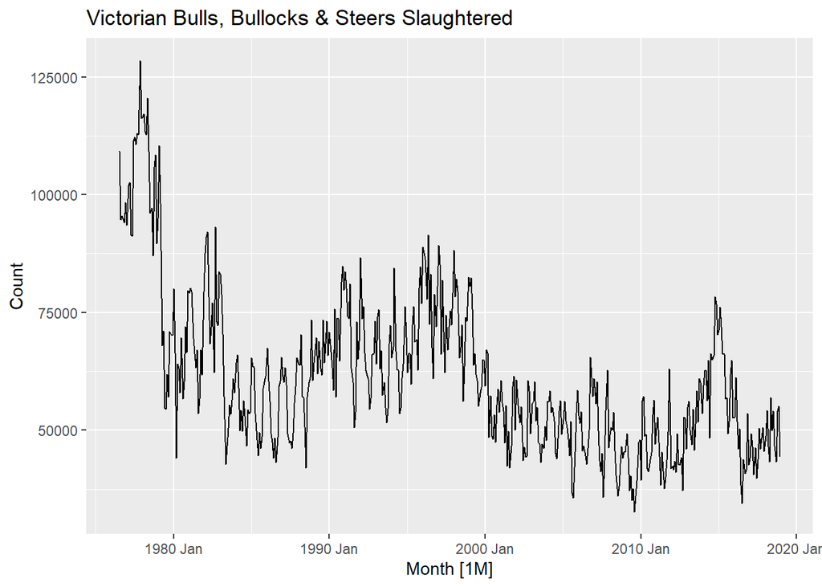

```r
# 2. Slaughter of Victorian “Bulls, bullocks and steers” from aus_livestock
victorian_slaughter <- aus_livestock %>%
  filter(Animal == "Bulls, bullocks and steers", State == "Victoria")

# Plot raw data
victorian_slaughter %>%
  autoplot(Count) +
  labs(title = "Victorian Bulls, Bullocks & Steers Slaughtered", y = "Count")
```

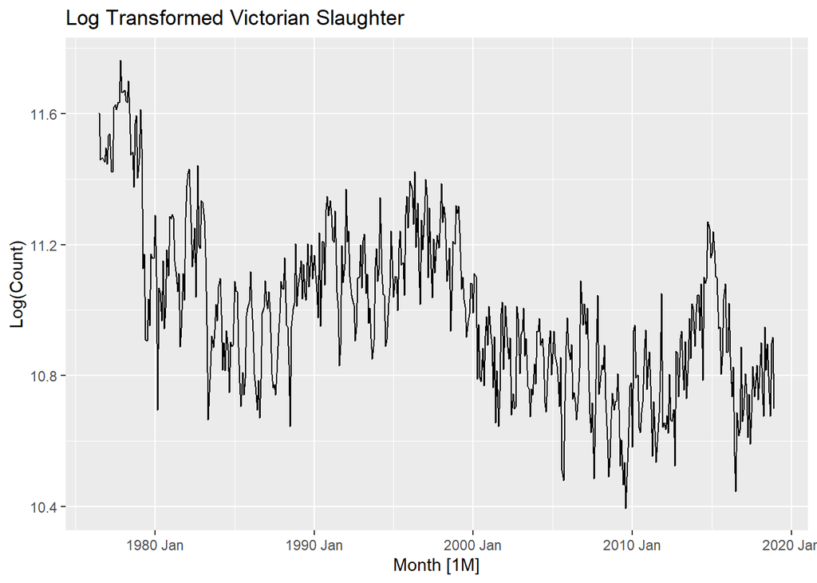

```r
# Log transformation (if necessary)
victorian_slaughter %>%
  mutate(log_Count = log(Count)) %>%
  autoplot(log_Count) +
  labs(title = "Log Transformed Victorian Slaughter", y = "Log(Count)")
```

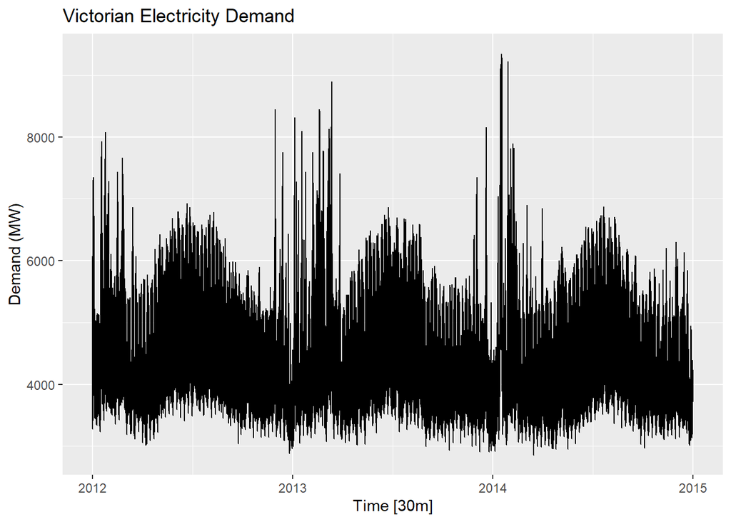

```r
# 3. Victorian Electricity Demand from vic_elec
vic_electricity <- vic_elec %>%
  select(Time, Demand)

# Plot raw electricity demand
vic_electricity %>%
  autoplot(Demand) +
  labs(title = "Victorian Electricity Demand", y = "Demand (MW)")
```

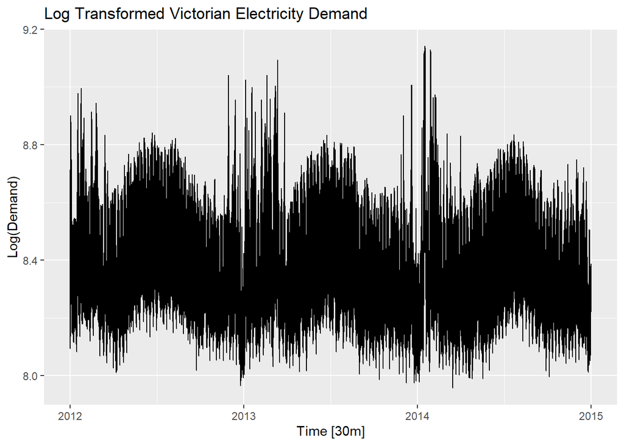

```r
# Apply log transformation if variance is unstable
vic_electricity %>%
  mutate(log_Demand = log(Demand)) %>%
  autoplot(log_Demand) +
  labs(title = "Log Transformed Victorian Electricity Demand", y = "Log(Demand)")
```

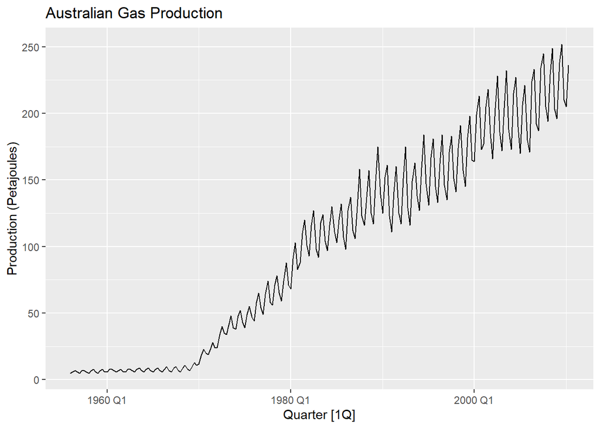

```r
# 4. Gas production from aus_production
gas_production <- aus_production %>%
  select(Quarter, Gas)

# Plot raw gas production
gas_production %>%
  autoplot(Gas) +
  labs(title = "Australian Gas Production", y = "Production (Petajoules)")
```

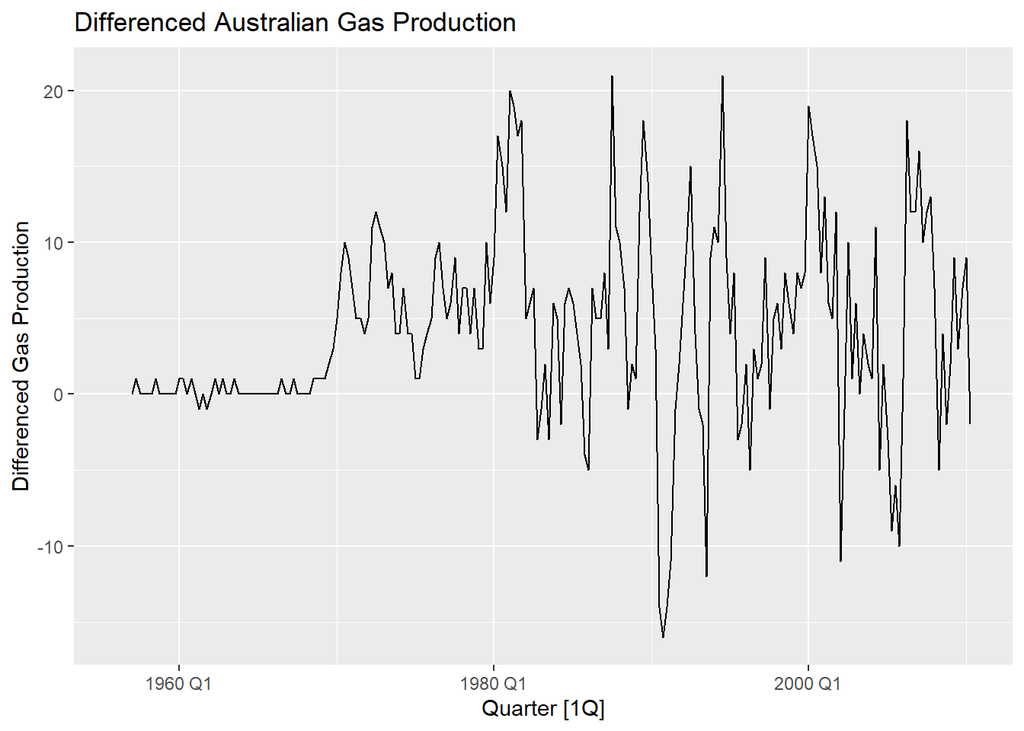

```r
# Seasonal difference transformation (if necessary)
gas_production %>%
  mutate(diff_Gas = difference(Gas, lag = 4)) %>%
  autoplot(diff_Gas) +
  labs(title = "Differenced Australian Gas Production", y = "Differenced Gas Production")
```

The transformation analysis for the selected time series highlights different patterns and necessary adjustments to improve interpretability. The **United States GDP** exhibits an exponential growth trend, making a **log transformation** effective in stabilizing variance and linearizing the trend over time. Similarly, the **Victorian slaughter data** for bulls, bullocks, and steers may show increasing fluctuations, where a **log transformation** helps reduce heteroscedasticity. The **Victorian electricity demand** often displays strong seasonal variation, and applying a **log transformation** can help stabilize variance while preserving seasonal patterns. Lastly, the **Australian gas production** series has noticeable seasonal fluctuations, making a **seasonal differencing transformation (lag = 4 for quarterly data)** useful in removing seasonal effects and revealing underlying trends. These transformations improve model performance and make trends and patterns more interpretable for further time series analysis.

**Exercise 3.3** What Box-Cox transformation would you select for your canadian gas data ?

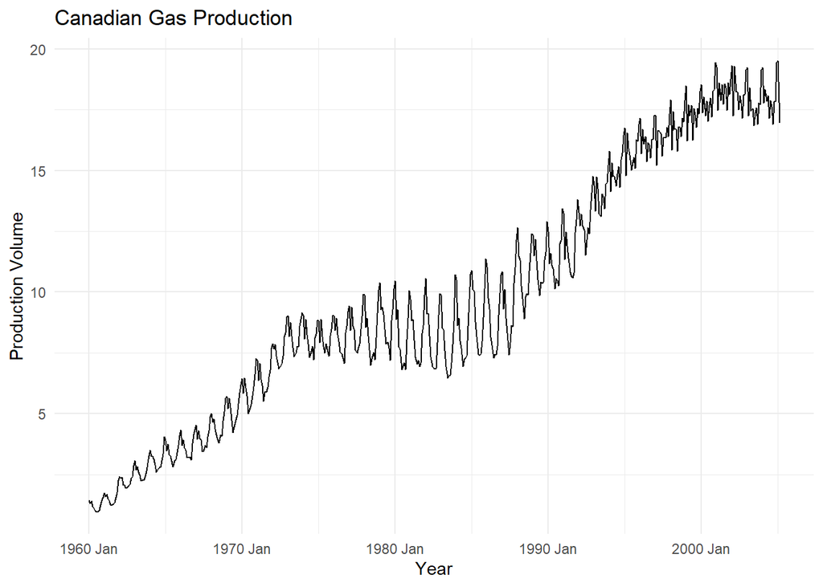

```r
# Plot raw Canadian gas production data
canadian_gas %>%
  autoplot(Volume) +
  labs(title = "Canadian Gas Production",
       y = "Production Volume",
       x = "Year") +
  theme_minimal()
```

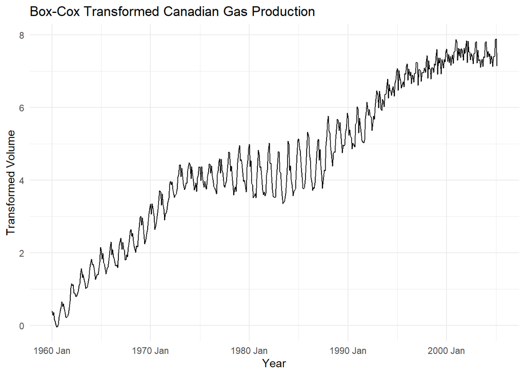

```r
# Estimate optimal lambda for Box-Cox transformation
lambda <- canadian_gas %>% features(Volume, features = guerrero) %>% pull(lambda_guerrero)

# Apply the Box-Cox transformation and plot
canadian_gas %>%
  mutate(BoxCox_Volume = box_cox(Volume, lambda)) %>%
  autoplot(BoxCox_Volume) +
  labs(title = "Box-Cox Transformed Canadian Gas Production",
       y = "Transformed Volume",
       x = "Year") +
  theme_minimal()
```

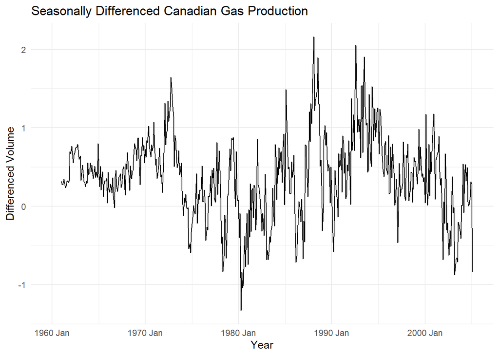

```r
# Apply seasonal differencing (lag = 12 for monthly data)
canadian_gas %>%
  mutate(Seasonally_Differenced = difference(Volume, lag = 12)) %>%
  autoplot(Seasonally_Differenced) +
  labs(title = "Seasonally Differenced Canadian Gas Production",
       y = "Differenced Volume",
       x = "Year") +
  theme_minimal()
```

```r
library(readxl)
library(httr)
library(openxlsx)
url <- 'https://raw.githubusercontent.com/joewarner89/Data-624-Predictive-Anaytics/main/workspace/retail.xlsx'

temp_file <- tempfile(fileext = ".xlsx")  # Create a temporary file

download.file(url, temp_file, mode = "wb")  # Download
retail <- read_excel(temp_file, skip = 1)  # Read the Excel file

head(retail)
```

```
## # A tibble: 6 × 190
##   `Series ID`         A3349335T A3349627V A3349338X A3349398A A3349468W
##   <dttm>                  <dbl>     <dbl>     <dbl>     <dbl>     <dbl>
## 1 1982-04-01 00:00:00      303.      41.7      63.9      409.      65.8
## 2 1982-05-01 00:00:00      298.      43.1      64        405.      65.8
## 3 1982-06-01 00:00:00      298       40.3      62.7      401       62.3
## 4 1982-07-01 00:00:00      308.      40.9      65.6      414.      68.2
## 5 1982-08-01 00:00:00      299.      42.1      62.6      404.      66
## 6 1982-09-01 00:00:00      305.      42        64.4      412.      62.3
## # ℹ 184 more variables: A3349336V <dbl>, A3349337W <dbl>, A3349397X <dbl>,
## #   A3349399C <dbl>, A3349874C <dbl>, A3349871W <dbl>, A3349790V <dbl>,
## #   A3349556W <dbl>, A3349791W <dbl>, A3349401C <dbl>, A3349873A <dbl>,
## #   A3349872X <dbl>, A3349709X <dbl>, A3349792X <dbl>, A3349789K <dbl>,
## #   A3349555V <dbl>, A3349565X <dbl>, A3349414R <dbl>, A3349799R <dbl>,
## #   A3349642T <dbl>, A3349413L <dbl>, A3349564W <dbl>, A3349416V <dbl>,
## #   A3349643V <dbl>, A3349483V <dbl>, A3349722T <dbl>, A3349727C <dbl>, …
```

```r
myts <- ts(retail[,"A3349873A"],
           frequency=12, start=c(1982,4))

# Find lambda for each series
lambda_myts <- find_lambda(myts)
```

```
## [1] "Optimal Lambda for series: 0.127636859661548"
```

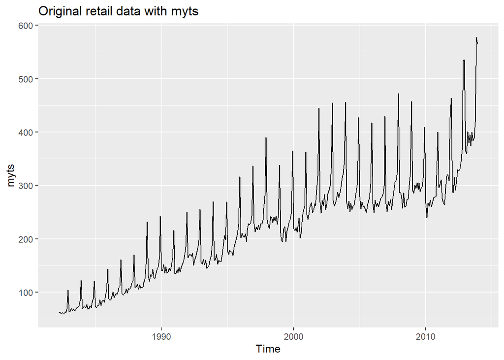

```r
myts_transformed <- BoxCox(myts,lambda_myts)

autoplot(myts) + ggtitle("Original retail data with myts")
```

**Exercise 3.5**

For the following series, find an appropriate Box-Cox transformation in order to stabilise the variance. Tobacco from aus_production, Economy class passengers between Melbourne and Sydney from ansett, and Pedestrian counts at Southern Cross Station from pedestrian.

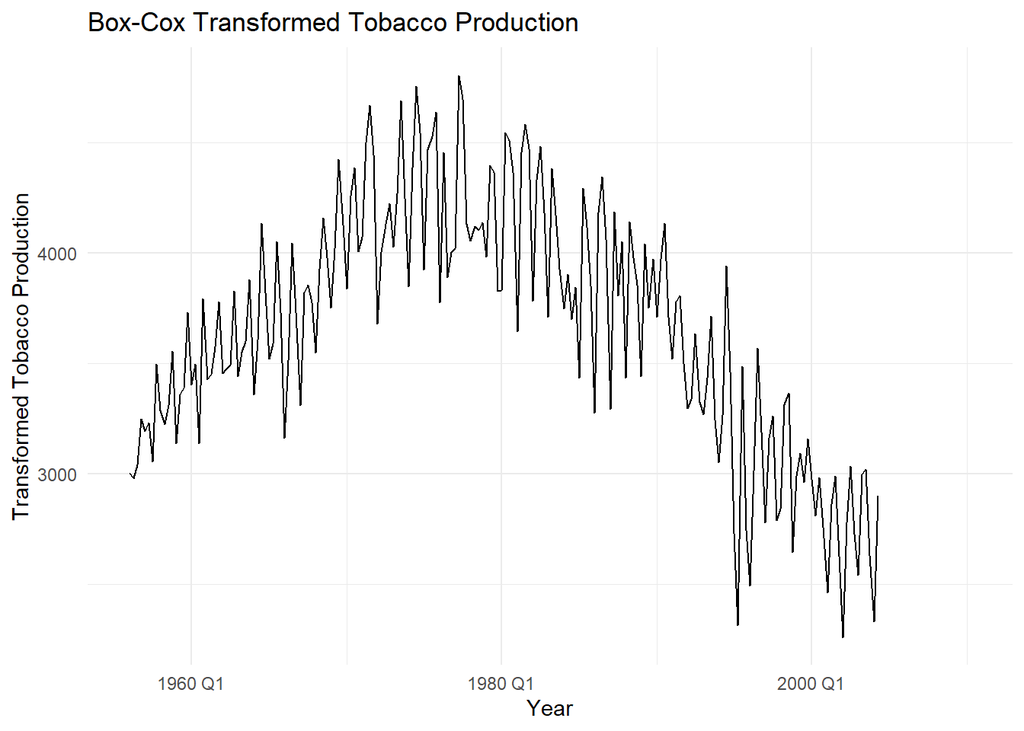

```r
# Load necessary libraries


# Estimate optimal Box-Cox lambda for Tobacco
lambda_tobacco <- aus_production %>%
  features(Tobacco, features = guerrero) %>%
  pull(lambda_guerrero)

# Apply Box-Cox transformation
aus_production %>%
  mutate(Tobacco_BoxCox = box_cox(Tobacco, lambda_tobacco)) %>%
  autoplot(Tobacco_BoxCox) +
  labs(title = "Box-Cox Transformed Tobacco Production",
       y = "Transformed Tobacco Production",
       x = "Year") +
  theme_minimal()
```

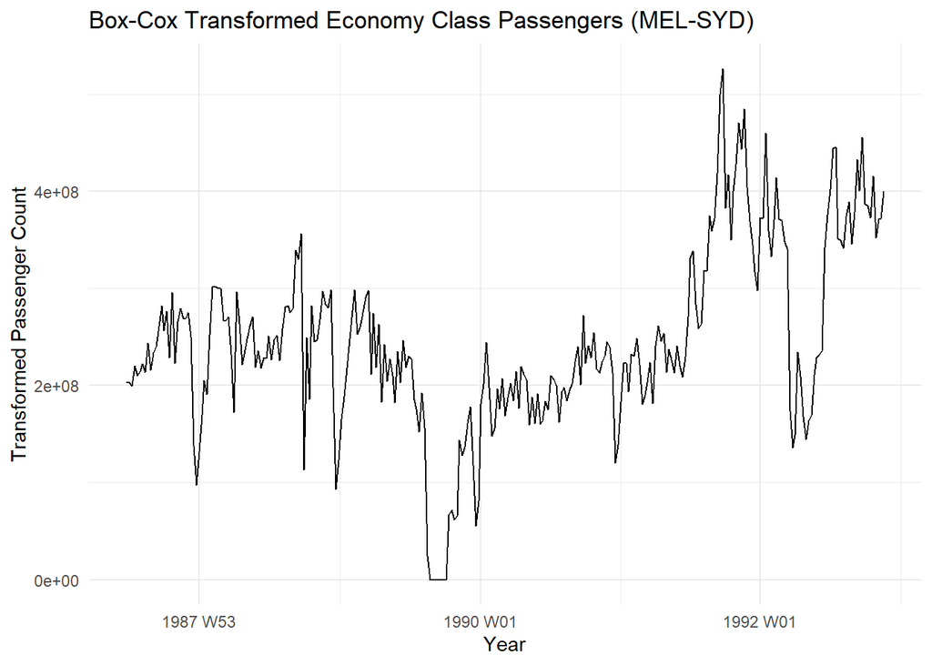

```r
# Estimate optimal Box-Cox lambda for Economy class passengers
lambda_passengers <- ansett %>%
  filter(Class == "Economy", Airports == "MEL-SYD") %>%
  features(Passengers, features = guerrero) %>%
  pull(lambda_guerrero)

# Apply Box-Cox transformation
ansett %>%
  filter(Class == "Economy", Airports == "MEL-SYD") %>%
  mutate(Passengers_BoxCox = box_cox(Passengers, lambda_passengers)) %>%
  autoplot(Passengers_BoxCox) +
  labs(title = "Box-Cox Transformed Economy Class Passengers (MEL-SYD)",
       y = "Transformed Passenger Count",
       x = "Year") +
  theme_minimal()
```